# EasyAovWlxPlot_help

wentao

2020/1/11

# 差异分析完整解决方案

## EasyAovWlxPlot 使用指南

安装EasyAovWlxPlot包

```r
library(devtools)
# install_github("taowenmicro/EasyAovWlxPlot")
```

导入包

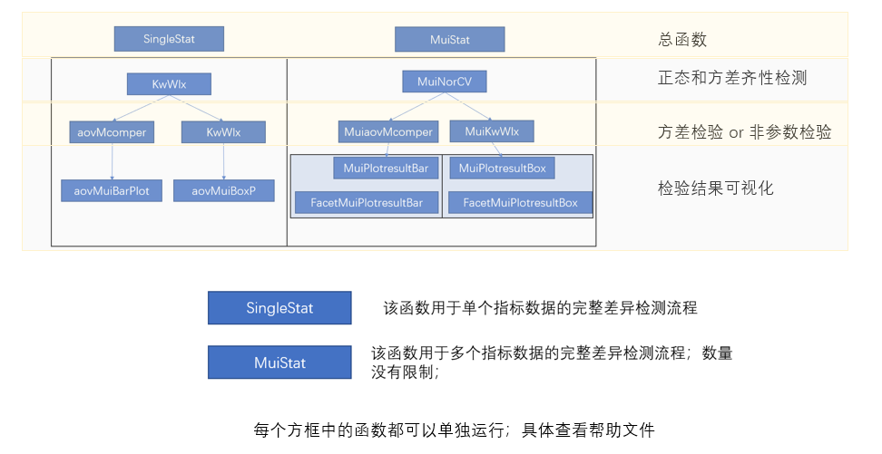

image

```r
library(EasyAovWlxPlot)
library(ggplot2)
#使用内置数据
data(data_wt)
```

### 基于单个指标的统计分析

正态检验和方差齐性分析

```r
# ?NorNorCVTest
##使用案例
NorCV = NorNorCVTest(data = data_wt, i= 4,method_cv = "leveneTest")
#提取正态检验结果
NorCV[[1]]
```

```
##             No         Name         W   p.value norm.test
## 1            1           CF 0.9077245 0.4105296      Norm
## 2            2           CK 0.9986271 0.9292195      Norm
## 3            3          Rhi 0.9501277 0.5698609      Norm
## 4            4           WT 0.8781602 0.3190147      Norm
## 5 Test Method: Shapiro-Wilk        NA        NA      <NA>
```

```r
#提取方差齐性检验结果
NorCV[[2]]
```

```
## [1] 0.6944591
```

### 方差分析(aovMcomper)

- data:输入数据框，第一列为样本编号，第二列为分组，注意分组标签必须设定为group，第三列以后就是妮妮测定或者收集的指标了
- i:代表您想要进行统计的列，比如：第三列：i = 3
- method_Mc:选择需要使用的多重比较方法，这里又多种方法可供选择：method_Mc == “LSD”;method_Mc == “SNK”;method_Mc == “Duncan”;method_Mc == “scheffe”

```r
# ?aovMcomper
result= aovMcomper (data = data_wt, i= 5,method_Mc = "Tukey")
# 提取多重比较结果
result[[1]]
```

```
##     groups group
## CF      a     CF
## CK      ab    CK
## Rhi      b   Rhi
## WT      ab    WT
```

```r
#提取方差检验结果
result[[2]]
```

```
## Call:
##    aov(formula = count ~ group, data = ss)
##
## Terms:
##                      group  Residuals
## Sum of Squares  8.0292e+14 3.6672e+14
## Deg. of Freedom          3          8
##
## Residual standard error: 6770524
## Estimated effects may be unbalanced
```

### 非参数检验

两个参数代表的意义与方差分析的两个相同；

- data:输入数据框，第一列为样本编号，第二列为分组，注意分组标签必须设定为group，第三列以后就是妮妮测定或者收集的指标了
- i:代表您想要进行统计的列，比如：第三列：i = 3

```r
# ?KwWlx
res = KwWlx(data = data_wt, i= 4)
# 调用非参数两两比较结果：字母标记展示
res[[1]]
```

```
##     groups group
## CF       a    CF
## CK       a    CK
## Rhi      a   Rhi
## WT       a    WT
```

```r
#表格展示两两之间差异结果
res[[2]]
```

```
## # A tibble: 6 x 8
##   .y.   group1 group2     p p.adj p.format p.signif method
##   <chr> <chr>  <chr>  <dbl> <dbl> <chr>    <chr>    <chr>
## 1 count CF     CK       0.1   0.6 0.1      ns       Wilcoxon
## 2 count CF     Rhi      0.2   0.8 0.2      ns       Wilcoxon
## 3 count CF     WT       0.2   0.8 0.2      ns       Wilcoxon
## 4 count CK     Rhi      0.1   0.6 0.1      ns       Wilcoxon
## 5 count CK     WT       0.2   0.8 0.2      ns       Wilcoxon
## 6 count Rhi    WT       0.7   0.8 0.7      ns       Wilcoxon
```

### 柱状图展示方差分析或非参数检验结果（aovMuiBarPlot）

- data：输入数据框，第一列为样本编号，第二列为分组，注意分组标签必须设定为group，第三列以后就是测定或者收集的指标了
- i：代表您想要进行统计的列，比如：第三列：i = 3
- sig_show：代表差异展示方式；sig_show =“abc”是使用字母表示;sig_show =“line”是使用连线和星号表示；如果是NA，那么就不显示显著性结果
- result：代表显著性差异分析结果，是一个数据框，第一列是显著性差异字母，第二列是分组group

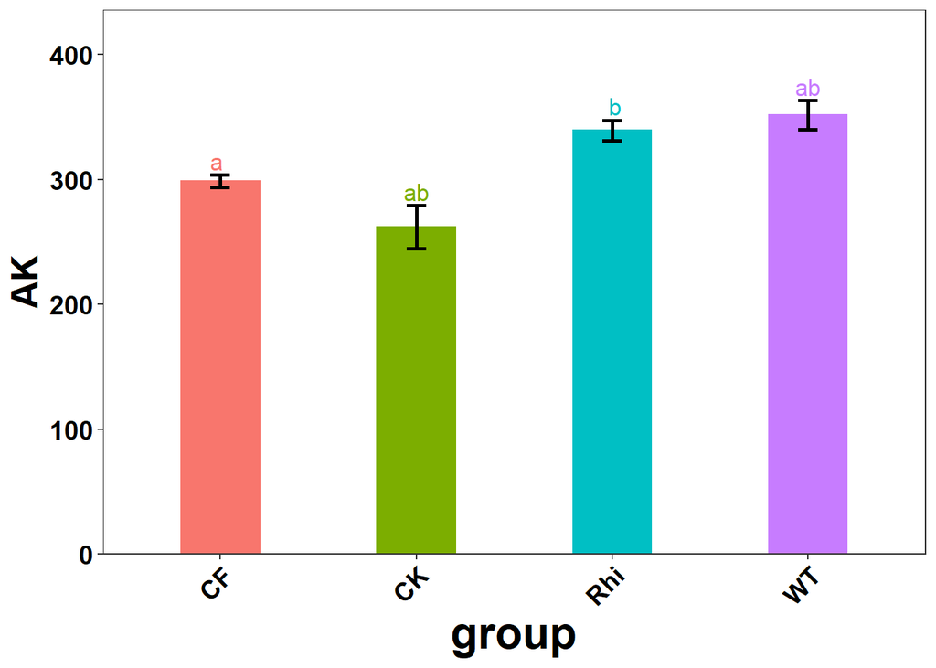

```r
# ?aovMuiBarPlot
###----使用方差检验结果和多重比较结果做展示：  柱状图展示
PlotresultBar = aovMuiBarPlot(data = data_wt, i= 3,sig_show ="abc",result = result[[1]])
#提取结果
PlotresultBar[[1]]
```

```r
#提取方差分析或非参数检验结果
PlotresultBar[[2]]
```

```
##   Row.names groups group  mean        SD
## 1        CF     a     CF 298.8  4.800000
## 2        CK     ab    CK 262.0 17.069271
## 3       Rhi      b   Rhi 339.2  7.989994
## 4        WT     ab    WT 351.6 11.572381
```

- data：输入数据框，第一列为样本编号，第二列为分组，注意分组标签必须设定为group，第三列以后就是测定或者收集的指标了
- i：代表您想要进行统计的列，比如：第三列：i = 3
- sig_show：代表差异展示方式；sig_show =“abc”是使用字母表示;sig_show =“line”是使用连线和星号表示；如果是NA，那么就不显示显著性结果
- result：代表显著性差异分析结果，是一个数据框，第一列是显著性差异字母，第二列是分组group

```r
# ?aovMuiBoxP
# #使用案例
PlotresultBox = aovMuiBoxP(data = data_wt, i= 3,sig_show ="abc",result = result[[1]])
```

```
## [1] 3
```

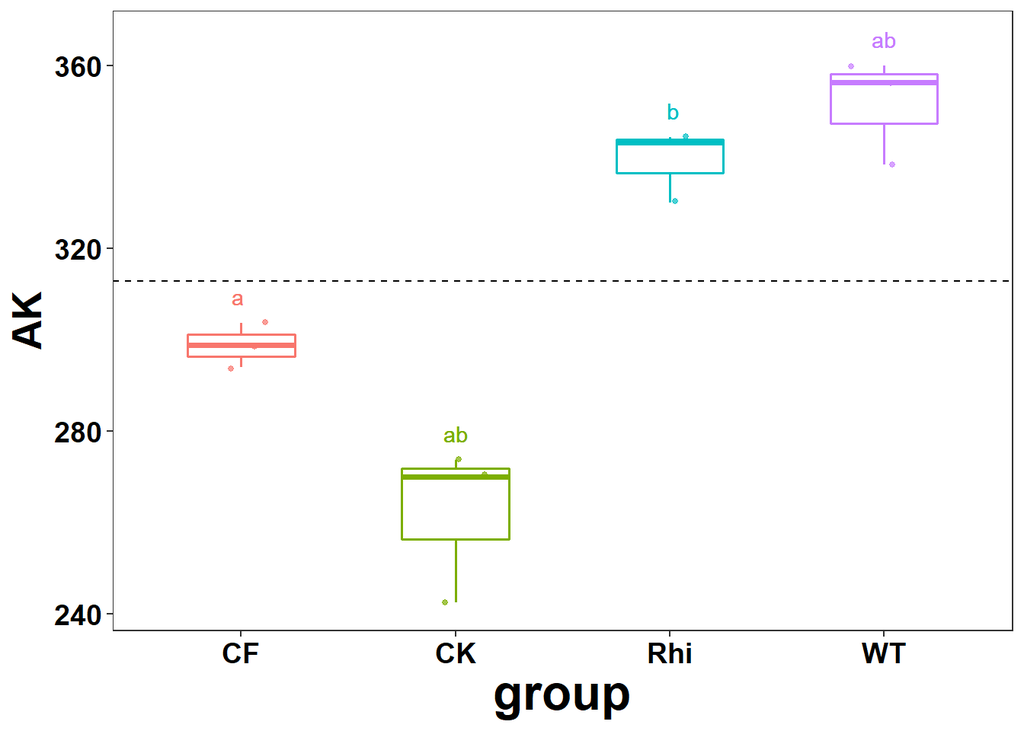

```r
#提取图片
p = PlotresultBox[[1]]
p
```

```r
# 提取检验结果
PlotresultBox[[2]]
```

```
##      ID group    dd stat      y
## 1   CF1    CF 303.6   a  309.48
## 2   CF2    CF 298.8   a  309.48
## 3   CF3    CF 294.0   a  309.48
## 4   CK1    CK 242.4   ab 279.48
## 5   CK2    CK 273.6   ab 279.48
## 6   CK3    CK 270.0   ab 279.48
## 7  Rhi1   Rhi 330.0    b 350.28
## 8  Rhi2   Rhi 343.2    b 350.28
## 9  Rhi3   Rhi 344.4    b 350.28
## 10  WT1    WT 338.4   ab 365.88
## 11  WT2    WT 356.4   ab 365.88
## 12  WT3    WT 360.0   ab 365.88
```

### 多个指标同时做正态检验和方差齐性分析（MuiNorCV）

这里对多组数据进行分析，结果我是用T或F代表，方便阅读。

- data：输入数据框，第一列为样本编号，第二列为分组，注意分组标签必须设定为group，第三列以后就是测定或者收集的指标了
- num：代表您想要进行统计的列,这里可以输入多个列，只需要指定列号即可：例如：num = c(4:6)
- method_cv：代表选择方差齐性的方法，有两种可供选择：method_cv == “bartlett.test” ;method_cv == “leveneTest”

```r
dim(data_wt)
```

```
## [1] 12 12
```

```r
# ?MuiNorCV
# 使用案例
norCv = MuiNorCV(data = data_wt,num = c(4:10),method_cv = "leveneTest")
#展示正态检验和方差齐性结果
norCv
```

```
##      DI      cor     CV
## [1,] "AP"    "TRUE"  "TRUE"
## [2,] "bac"   "TRUE"  "TRUE"
## [3,] "fun"   "FALSE" "TRUE"
## [4,] "micro" "TRUE"  "TRUE"
## [5,] "NH4-N" "TRUE"  "TRUE"
## [6,] "NO3-N" "TRUE"  "TRUE"
## [7,] "pH"    "FALSE" "TRUE"
```

#### 多个指标方差检验（MuiaovMcomper）

- data：输入数据框，第一列为样本编号，第二列为分组，注意分组标签必须设定为group，第三列以后就是妮妮测定或者收集的指标了
- num：代表您想要进行统计的列,这里可以输入多个列，只需要指定列号即可：例如：num = c(4:6)
- method_Mc：选择需要使用的多重比较方法，这里又多种方法可供选择：method_Mc == “LSD”;method_Mc == “SNK”;method_Mc == “Duncan”;method_Mc == “scheffe”

```r
# ? MuiaovMcomper
# #使用案例
result = MuiaovMcomper(data = data_wt,num = c(4:6),method_Mc = "Tukey")
#提取每个指标方差检验多重比较结果
result
```

```
##     AP bac fun
## CF  a   a   a
## CK   b  ab  a
## Rhi ab   b   b
## WT  ab  ab  a
```

### 多个指标非参数检验（MuiKwWlx）

- data：输入数据框，第一列为样本编号，第二列为分组，注意分组标签必须设定为group，第三列以后就是测定或者收集的指标了
- num：代表您想要进行统计的列,这里可以输入多个列，只需要指定列号即可：例如：num = c(4:6)

```r
# ? MuiKwWlx
# #使用案例
result = MuiKwWlx(data = data_wt,num = c(4:6))
#提取每个指标非参数检验多重比较结果
result
```

```
##     AP bac fun
## CF   a   a   a
## CK   a   a   a
## Rhi  a   a   a
## WT   a   a   a
```

### 多组数据可视化差异分析结果： 柱状图（MuiPlotresultBar）

我让该函数自动保存每个指标的出图文件到当前文件夹中。这些文件以该指标名称命名；

- data：输入数据框，第一列为样本编号，第二列为分组，注意分组标签必须设定为group，第三列以后就是妮妮测定或者收集的指标了
- num：代表您想要进行统计的列,这里可以输入多个列，只需要指定列号即可：例如：num = c(4:6)
- sig_show：代表差异展示方式；sig_show =“abc”是使用字母表示;sig_show =“line”是使用连线和星号表示；如果是NA，那么就不显示显著性结果
- result：代表显著性差异分析结果，是一个数据框，每一列是显著性标记字母,MuiKwWlx

```r
# ?MuiPlotresultBar
# # #使用案例
result = MuiKwWlx(data = data_wt,num = c(4:6))
result
```

```
##     AP bac fun
## CF   a   a   a
## CK   a   a   a
## Rhi  a   a   a
## WT   a   a   a
```

```r
# #结果直接输出到文件夹中
MuiPlotresultBar(data = data_wt,num = c(4:6),result = result ,sig_show ="line")
```

```
## [1] 4
```

```
## [1] 5
```

```
## [1] 6
```

### 多组数据可视化差异分析结果：箱线图（MuiPlotresultBox）

我让该函数自动保存每个指标的出图文件到当前文件夹中。这些文件以该指标名称命名；

- data：输入数据框，第一列为样本编号，第二列为分组，注意分组标签必须设定为group，第三列以后就是妮妮测定或者收集的指标了
- num：代表您想要进行统计的列,这里可以输入多个列，只需要指定列号即可：例如：num = c(4:6)
- sig_show：代表差异展示方式；sig_show =“abc”是使用字母表示;sig_show =“line”是使用连线和星号表示；如果是NA，那么就不显示显著性结果
- result：代表显著性差异分析结果，是一个数据框，每一列是显著性标记字母,MuiKwWlx

```r
# ?MuiPlotresultBox
#使用案例
result = MuiKwWlx(data = data_wt,num = c(4:8))
result
```

```
##     AP bac fun micro NH4-N
## CF   a   a   a     a     a
## CK   a   a   a     a     a
## Rhi  a   a   a     a     a
## WT   a   a   a     a     a
```

```r
# #直接出图到文件夹中
MuiPlotresultBox(data = data_wt,num = c(4:8),result = result,sig_show ="abc")
```

```
## [1] 4
```

```
## [1] 5
```

```
## [1] 6
```

```
## [1] 7
```

```
## [1] 8
```

#### 差异结果展示：分面展示柱状图：(FacetMuiPlotresultBar)

- data：输入数据框，第一列为样本编号，第二列为分组，注意分组标签必须设定为group，第三列以后就是妮妮测定或者收集的指标了
- num：代表您想要进行统计的列,这里可以输入多个列，只需要指定列号即可：例如：num = c(4:6)
- sig_show：代表差异展示方式；sig_show =“abc”是使用字母表示;sig_show =“line”是使用连线和星号表示；如果是NA，那么就不显示显著性结果
- result：代表显著性差异分析结果，是一个数据框，每一列是显著性标记字母,MuiKwWlx
- ncol:代表分面展示每一行放几张图

```r
# ?FacetMuiPlotresultBar
# # #使用案例
result = MuiaovMcomper(data = data_wt,num = c(4:10),method_Mc = "Tukey")
result
```

```
##     AP bac fun micro NH4-N NO3-N pH
## CF  a   a   a     a      a     b  b
## CK   b  ab  a     a      a     b a
## Rhi ab   b   b     b     a    a   b
## WT  ab  ab  a     ab     a     b  b
```

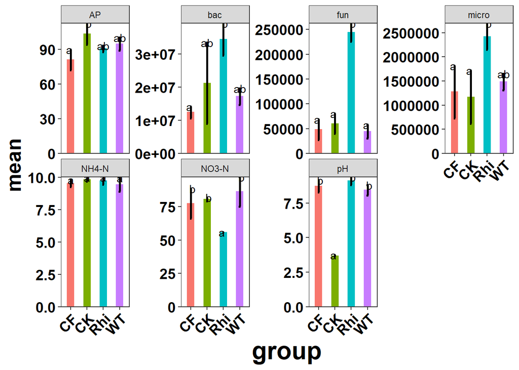

```r
result1 = FacetMuiPlotresultBar(data = data_wt,num = c(4:10),result = result,sig_show ="abc",ncol = 4 )
result1[[1]]
```

- data：输入数据框，第一列为样本编号，第二列为分组，注意分组标签必须设定为group，第三列以后就是妮妮测定或者收集的指标了
- num：代表您想要进行统计的列,这里可以输入多个列，只需要指定列号即可：例如：num = c(4:6)
- sig_show：代表差异展示方式；sig_show =“abc”是使用字母表示;sig_show =“line”是使用连线和星号表示；如果是NA，那么就不显示显著性结果
- result：代表显著性差异分析结果，是一个数据框，每一列是显著性标记字母,MuiKwWlx
- ncol:代表分面展示每一行放几张图

```r
# ?FacetMuiPlotresultBox
# #使用案例
result = MuiaovMcomper(data = data_wt,num = c(4:10),method_Mc = "Tukey")
result
```

```
##     AP bac fun micro NH4-N NO3-N pH
## CF  a   a   a     a      a     b  b
## CK   b  ab  a     a      a     b a
## Rhi ab   b   b     b     a    a   b
## WT  ab  ab  a     ab     a     b  b
```

```r
#
result1 = FacetMuiPlotresultBox(data = data_wt,num = c(4:10),result = result,sig_show ="abc",ncol = 2 )
```

```
## [1] 4
## [1] 5
## [1] 6
## [1] 7
## [1] 8
## [1] 9
## [1] 10
```

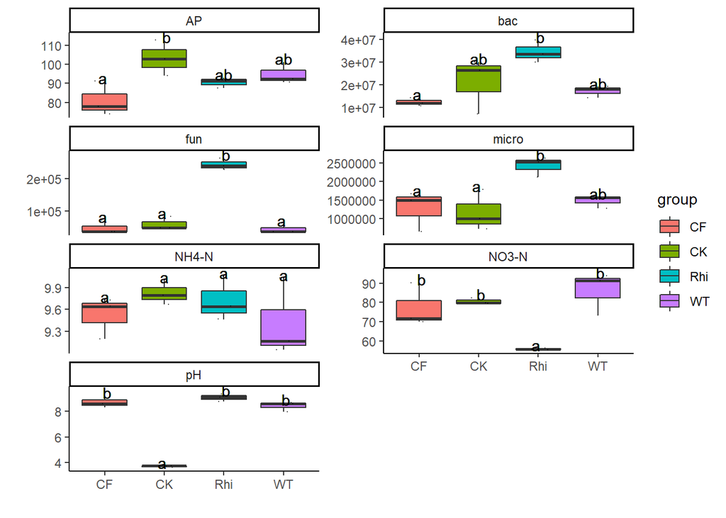

```r
result1[[1]]
```

### 单个指标一体化分析（SingleStat）

这个函数可以将我们的目标列做正态检验和方差齐性，然后根据结果选择方差检验或者多重比较方法，最后选择自己需要的出图方式和显著性标记方式展示。

- data：输入数据框，第一列为样本编号，第二列为分组，注意分组标签必须设定为group，第三列以后就是妮妮测定或者收集的指标了
- i：代表您想要进行统计的列，比如：第三列：i = 3
- method_Mc：选择需要使用的多重比较方法，这里又多种方法可供选择：method_Mc == “LSD”;method_Mc == “SNK”;method_Mc == “Duncan”;method_Mc == “scheffe”
- plot：可以选择需要的出图类型，柱状图和箱线图

```r
# ?SingleStat
# # #使用案例
# #输出结果第一个为图片，第二个是统计结果，第三个是统计方法
result = SingleStat(data = data_wt,plot = "bar",method_Mc = "Tukey",i= 4,sig_show ="abc")
```

```
## [1] "aov"
```

[figure not shown]

```r
# #导出图片
p = result[[1]]
p
```

### 多个指标一体化分析(MuiStat)

实现了多个指标批量整体运行；这个函数可以将我们的目标列做正态检验和方差齐性，然后根据结果选择方差检验或者多重比较方法，最后选择自己需要的出图方式和显著性标记方式展示。

data：输入数据框，第一列为样本编号，第二列为分组，注意分组标签必须设定为group，第三列以后就是妮妮测定或者收集的指标了

num：代表您想要进行统计的列,这里可以输入多个列，只需要指定列号即可：例如：num = c(4:6)

method_cv：代表选择方差齐性的方法，有两种可供选择：method_cv == “bartlett.test” ;method_cv == “leveneTest”

method_Mc：选择需要使用的多重比较方法，这里又多种方法可供选择：method_Mc == “LSD”;method_Mc == “SNK”;method_Mc == “Duncan”;method_Mc == “scheffe”

plot：可以选择需要的出图类型，柱状图和箱线图

sig_show：代表差异展示方式；sig_show =“abc”是使用字母表示;sig_show =“line”是使用连线和星号表示；如果是NA，那么就不显示显著性结果

ncol：代表分面展示每一行放几张图

plottype：输出图形是分面展示plottype =mui，还是单张展示:plottype == “single”

```r
# ?MuiStat
#使用案例
result = MuiStat(data = data_wt,num = c(4:10),method_cv = "leveneTest",method_Mc = "Tukey",sig_show  = "abc",ncol = 4,plot = "box",plottype = "mui")
```

```
## [1] 4
## [1] 5
## [1] 7
## [1] 8
## [1] 9
## [1] 6
## [1] 10
```

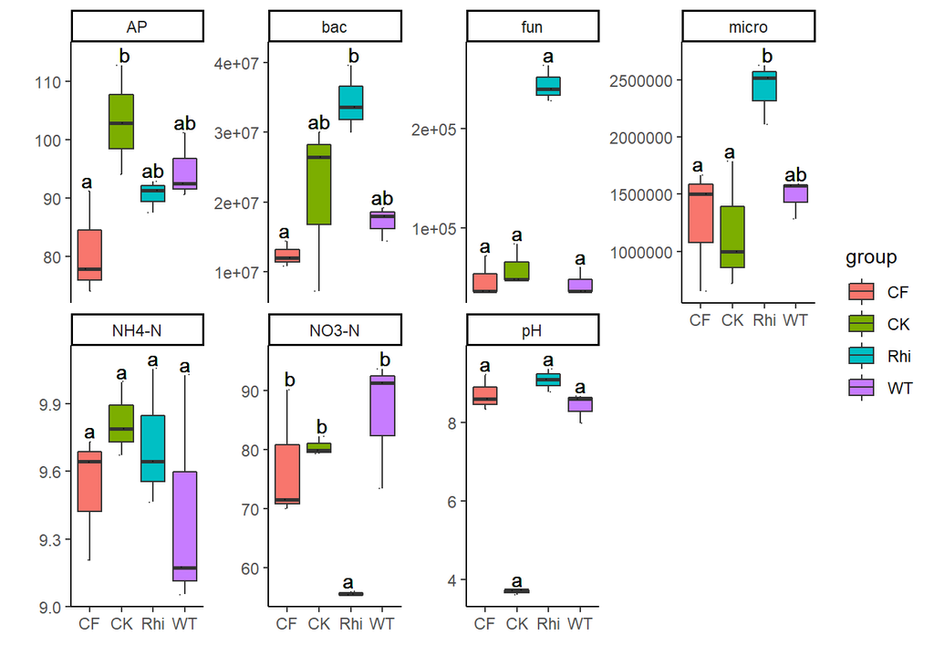

```r
result[[1]]
```